# AFCm

YALAOUI Akli & BOULAOUAD ADEL

1/26/2022

# Introduction :

L’objectif de ce tp est de déterminer les associations pertinentes entres les questions et les réponses dans un questionnaire qui aideront à comprendre l’état des lieux et prendre des décisions. Et cela en appliquant l’AFCM à ce questionnaire.

L’AFCM est une méthode d’analyse de données qui consiste à appliquer l’AFC à l’étude des tableaux qui sont résultats d’observations d’individus sur plus de deux variables qualitatives mises sous forme d’un tableau disjonctif complet.

Ce rapport est organisé comme suivant :

- Introduction
- Présentation du dataset
- Prétraitement des données
- Etude et visualisation des statistiques des données
- Préparation à l’AFCm
- AFCM sur le questionnaire
- AFC sur deux questions
- Conclusion

# Présentation du dataset :

Les données ont été recueillies par un questionnaire. Il est basé sur des recherches en temps réel au Nottingham Trent International College. Il vise à aider les chercheurs à découvrir les facteurs qui affectent les compétences de gestion du temps des étudiants.

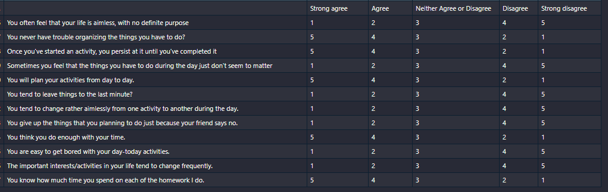

Les questions X6 à X17 et les types de réponse

## Importation des données :

Ici nous allons importer les données à partir du fichier csv, et découvrir le dataset :

```r
# Importer les données
data <- read.csv("International students Time management data.csv")

# Nombre de variables
print(ncol(data))
```

```
## [1] 21
```

```r
# Nombre d'individus
print(nrow(data))
```

```
## [1] 125
```

```r
# Le noms des variables
for(i in 1:ncol(data)){
  print(colnames(data)[i])
}
```

```
## [1] "Number"
## [1] "Age"
## [1] "Gender"
## [1] "Nationality"
## [1] "Program"
## [1] "Course"
## [1] "English"
## [1] "Academic"
## [1] "Attendance"
## [1] "X6"
## [1] "X7"
## [1] "X8"
## [1] "X9"
## [1] "X10"
## [1] "X11"
## [1] "X12"
## [1] "X13"
## [1] "X14"
## [1] "X15"
## [1] "X16"
## [1] "X17"
```

Donc on a 21 variables et 125 individus dans le dataset

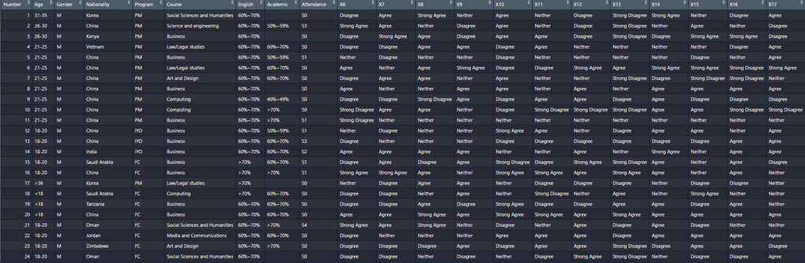

Overview du dataset

# Prétraitement des données :

On fait un summary pour voir les types des variables :

```r
summary(data)
```

```
##      Number        Age               Gender          Nationality
##  Min.   :  1   Length:125         Length:125         Length:125
##  1st Qu.: 32   Class :character   Class :character   Class :character
##  Median : 63   Mode  :character   Mode  :character   Mode  :character
##  Mean   : 63
##  3rd Qu.: 94
##  Max.   :125
##    Program             Course            English            Academic
##  Length:125         Length:125         Length:125         Length:125
##  Class :character   Class :character   Class :character   Class :character
##  Mode  :character   Mode  :character   Mode  :character   Mode  :character
##
##
##
##   Attendance             X6                 X7                 X8
##  Length:125         Length:125         Length:125         Length:125
##  Class :character   Class :character   Class :character   Class :character
##  Mode  :character   Mode  :character   Mode  :character   Mode  :character
##
##
##
##       X9                X10                X11                X12
##  Length:125         Length:125         Length:125         Length:125
##  Class :character   Class :character   Class :character   Class :character
##  Mode  :character   Mode  :character   Mode  :character   Mode  :character
##
##
##
##      X13                X14                X15                X16
##  Length:125         Length:125         Length:125         Length:125
##  Class :character   Class :character   Class :character   Class :character
##  Mode  :character   Mode  :character   Mode  :character   Mode  :character
##
##
##
##      X17
##  Length:125
##  Class :character
##  Mode  :character
##
##
##
```

La première variables Number est quantitative et elle représente uniquement un numéro séquentiel pour désigner un individu, donc on doit l’éliminer :

```r
data$Number <- NULL
```

On a remarqué qu’il y a des valeurs manquantes dans nos données, on va les détécter pour décider comment on va remédier à ce problème. D’abord on vérifie s’il y a des valeurs de types NA dans chaque colonnes

```r
for (i in 1: ncol(data)){
  print(sum(is.na(data[,i])))
}
```

```
## [1] 0
## [1] 0
## [1] 0
## [1] 0
## [1] 0
## [1] 0
## [1] 0
## [1] 0
## [1] 0
## [1] 0
## [1] 0
## [1] 0
## [1] 0
## [1] 0
## [1] 0
## [1] 0
## [1] 0
## [1] 0
## [1] 0
## [1] 0
```

On conclut qu’il n’y a pas de valeurs de type NA, donc on vérifie les chaine de characters vide :

```r
for (i in 1: ncol(data)){
  print(c(colnames(data)[i],sum((data[,i] == ""))/nrow(data)*100))
}
```

```
## [1] "Age" "0"
## [1] "Gender" "0"
## [1] "Nationality" "0"
## [1] "Program" "0"
## [1] "Course" "0"
## [1] "English" "4.8"
## [1] "Academic" "17.6"
## [1] "Attendance" "4.8"
## [1] "X6"  "1.6"
## [1] "X7" "0"
## [1] "X8"  "3.2"
## [1] "X9"  "5.6"
## [1] "X10" "0.8"
## [1] "X11" "1.6"
## [1] "X12" "2.4"
## [1] "X13" "0"
## [1] "X14" "0.8"
## [1] "X15" "0"
## [1] "X16" "1.6"
## [1] "X17" "0.8"
```

On remarque que la variable académique a un nombre important de valeurs manquantes ( 17.6%) par rapport aux autres variables. Nous allons opter à remplacer les valeurs manquantes dans chaque variables avec le mode de cette variable.Pour ce faire, on aura besoin d’une fonction qui retourne le mode d’une colonne :

```r
Mode <- function(u){
  tmp <- unique(u)
  tmp[which.max(tabulate(match(u,tmp)))]
}

# Le mode de la colonne académique
Mode(data$Academic)
```

```
## [1] "60%~70%"
```

Le remplissage des valeurs manquantes :

```r
for (i in 1: ncol(data)){
  data[data[,i] == "",i] <- Mode(data[,i])
}
```

On a nettoyé nos données avec succés, il n’y a plus de valeurs manquantes :

```r
for (i in 1: ncol(data)){
  print(c(colnames(data)[i],sum((data[,i] == ""))/nrow(data)*100))
}
```

```
## [1] "Age" "0"
## [1] "Gender" "0"
## [1] "Nationality" "0"
## [1] "Program" "0"
## [1] "Course" "0"
## [1] "English" "0"
## [1] "Academic" "0"
## [1] "Attendance" "0"
## [1] "X6" "0"
## [1] "X7" "0"
## [1] "X8" "0"
## [1] "X9" "0"
## [1] "X10" "0"
## [1] "X11" "0"
## [1] "X12" "0"
## [1] "X13" "0"
## [1] "X14" "0"
## [1] "X15" "0"
## [1] "X16" "0"
## [1] "X17" "0"
```

# Etude et visualisation des statistiques des données :

Dans cette section , nous allons commencer à explorer nos données en étudiant les modalités de chaque variables. On aura besoin d’une fonction qui va nous donner des graphes consisten pour chaque variables

```r
Cat_plot <- function(y,title){
  n <- table(y)
  barplot(n,las = 2,main=title,ylab = "Count")
  text(x =n, label = n,pos = 1, col = "red")

}
```

## La variable Age :

En regardant le graph ci-dessous, il est clair que la majorité des personnes interrogées appartenaient au groupe d’âge 21-25 ans. Il y avait 6 personnes de moins de 18 ans et 4 de plus de 36 ans.

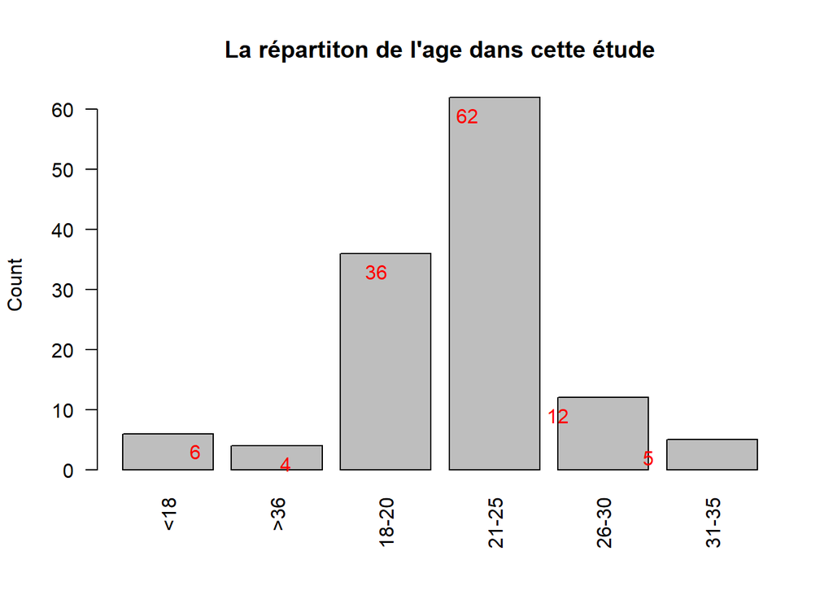

```r
Cat_plot(data$Age,"La répartiton de l'age dans cette étude")
```

## La variable Gender :

Il y avait une répartition presque égale entre les deux sexes dans l’enquête, 63 femmes et 62 hommes.

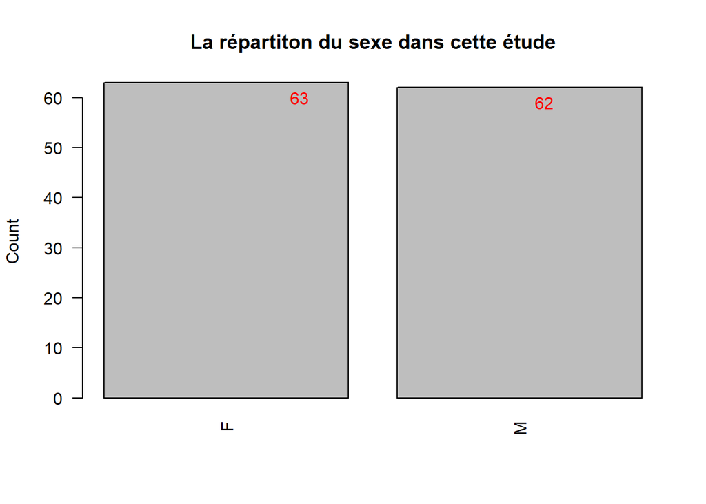

```r
Cat_plot(data$Gender,"La répartiton du sexe dans cette étude")
```

## La variable Nationality

La majorité (77) des étudiants interrogés étaient chinois, suivis par l’Arabie saoudite et la Corée à 6. La majorité des pays avaient 2 ou 1 étudiant interrogé.

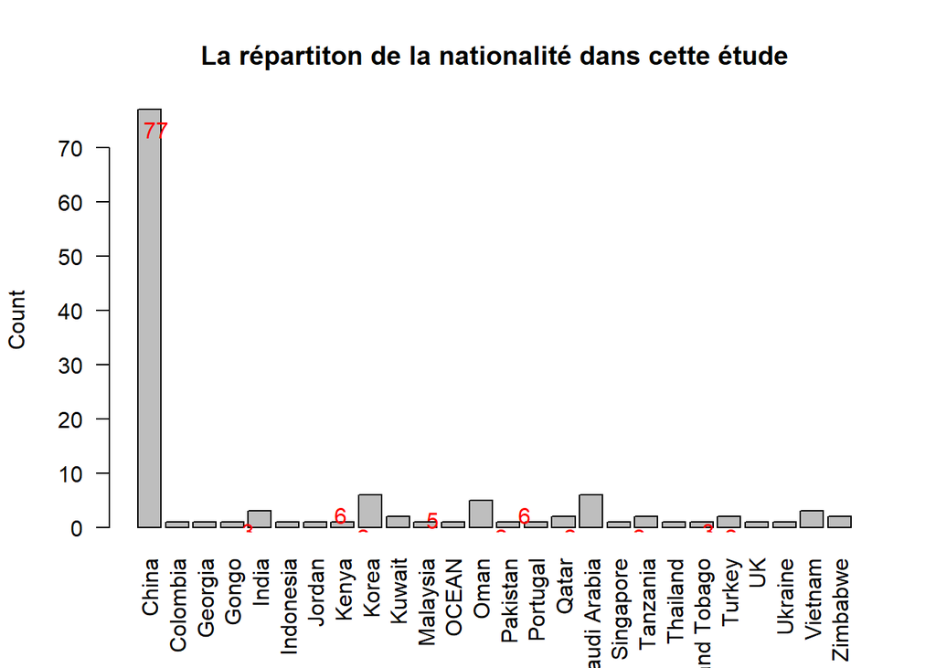

```r
Cat_plot(data$Nationality,"La répartiton de la nationalité dans cette étude")
```

## La variable Program :

La majorité des répondants au sondage étaient dans le programme PM, suivi du programme FC à 31 étudiants. Le programme de langue n’avait qu’un seul étudiant interrogé.

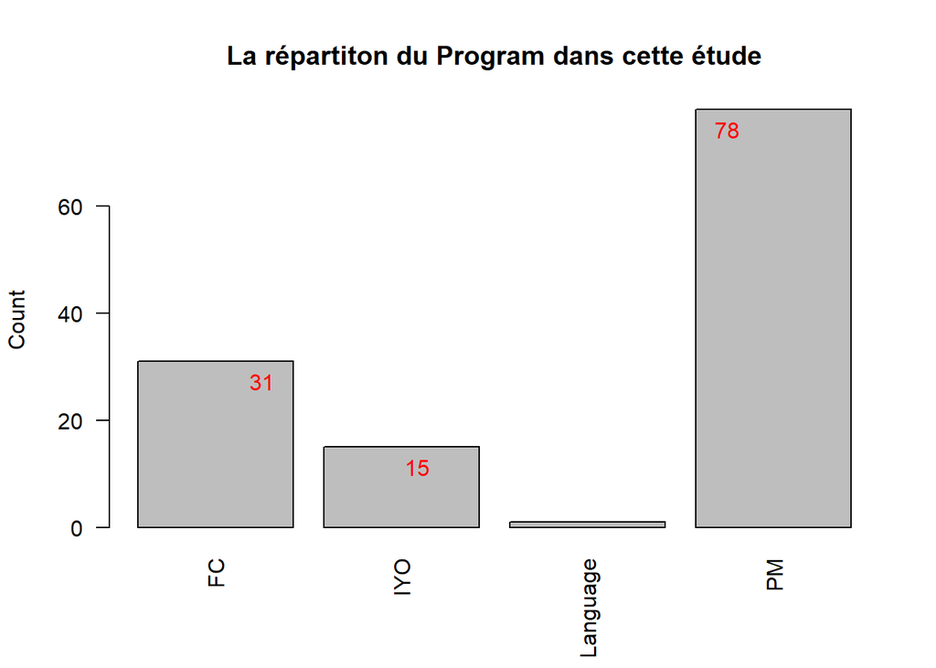

```r
Cat_plot(data$Program,"La répartiton du Program dans cette étude")
```

## La variable Course :

La plupart des étudiants interrogés suivaient le cours du Business (80), suivis de ceux du cours de Law/Legal Studies (14). Le cours sur Media and Communications a le plus petit nombre d’étudiants interrogés à 3.

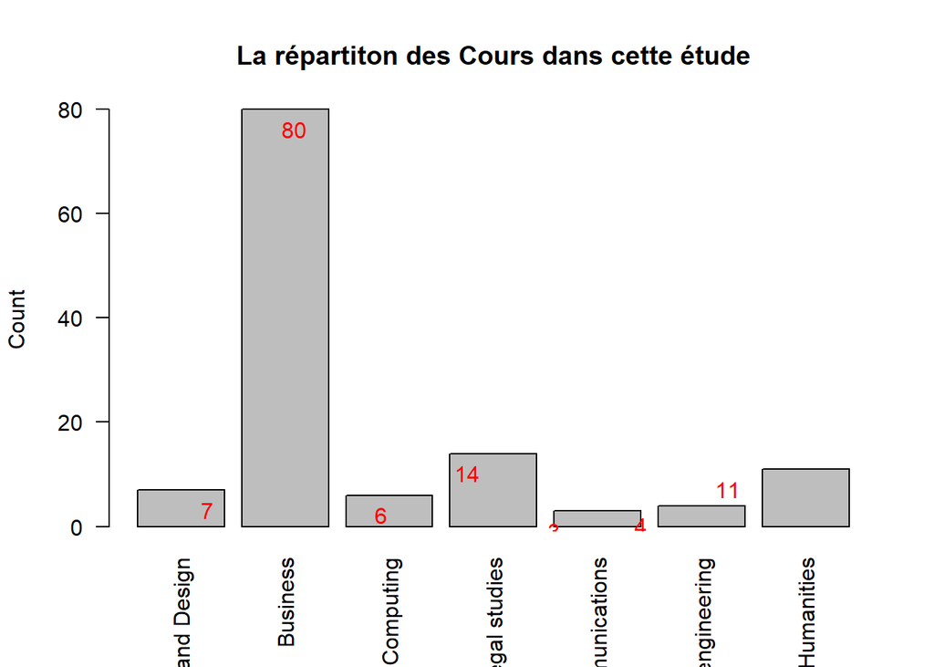

```r
Cat_plot(data$Course,"La répartiton des Cours dans cette étude")
```

## La variable English

Seuls 15 étudiants interrogés avaient des notes supérieures à 70%, la majorité des étudiants se situant entre 60 et 70%. Il y avait une seule personne qui était inférieure à 40 %.

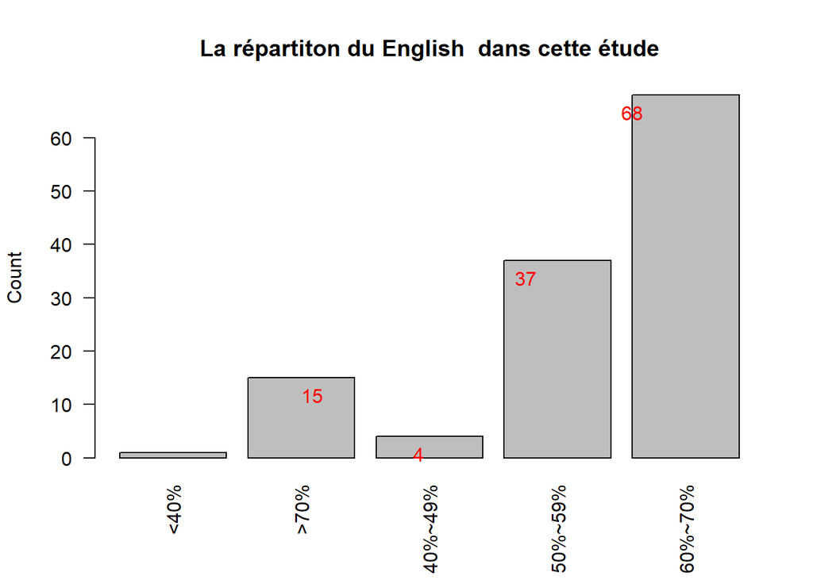

```r
Cat_plot(data$English,"La répartiton du English  dans cette étude")
```

## La variable Academic :

Les notes des cours académiques suivent un modèle similaire à ce que nous avons vu avec les notes des cours d’anglais, la majorité des étudiants interrogés se situent entre 60 et 70%, 13 se situant entre 70% et plus et2 avaient des notes inférieures à 40%.

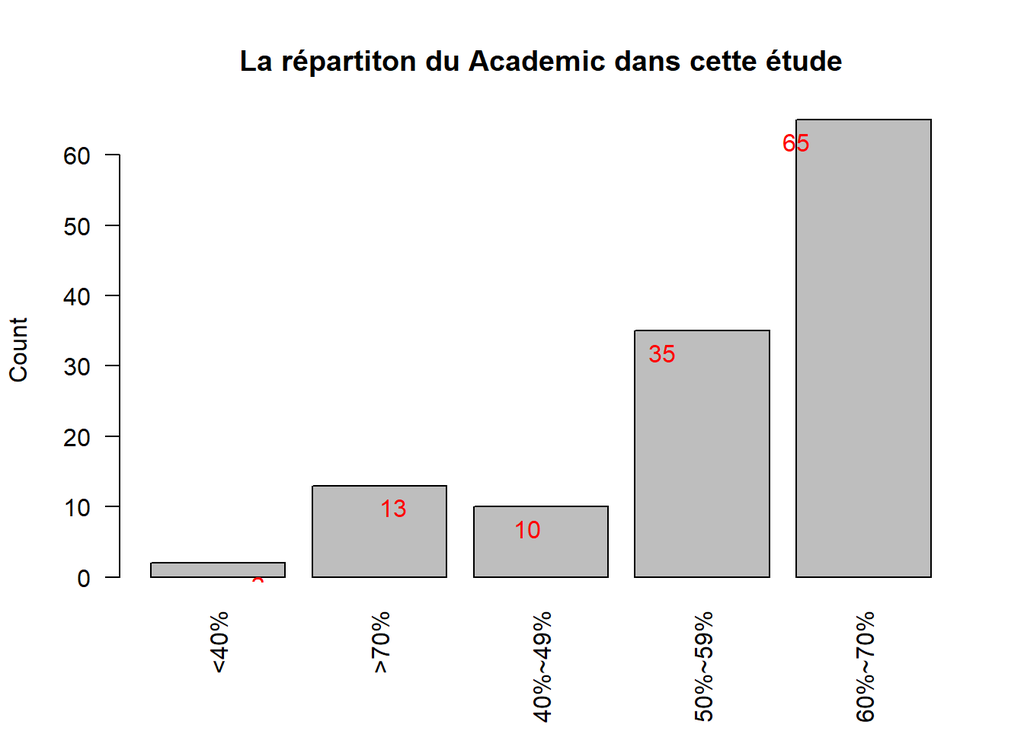

```r
Cat_plot(data$Academic,"La répartiton du Academic dans cette étude")
```

## La variable Attendance :

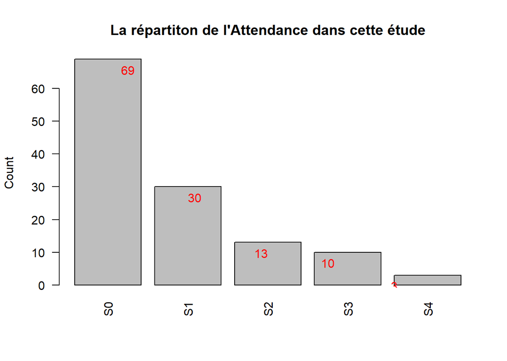

```r
Cat_plot(data$Attendance,"La répartiton de l'Attendance dans cette étude")
```

## La variable question 6 :

50 étudiants interrogés sont en désaccord avec l’affirmation selon laquelle leur vie est sans but, sans but précis, c’est la majorité. 23 étudiants interrogés étaient d’accord avec la déclaration, tandis que 27 étudiants n’avaient aucun sentiment dans les deux sens.

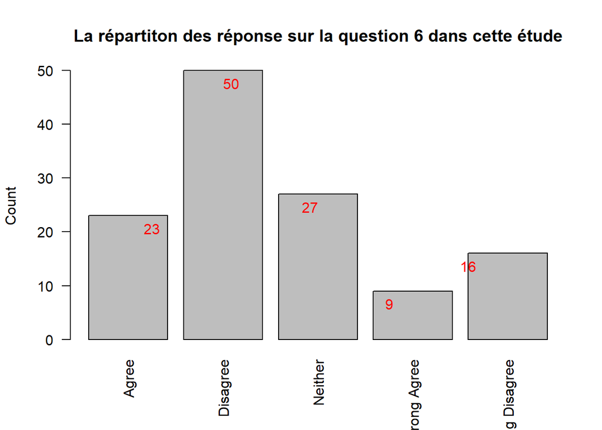

```r
Cat_plot(data$X6,"La répartiton des réponse sur la question 6 dans cette étude")
```

## La variable question 7 :

40 étudiants interrogés ont déclaré qu’ils avaient du mal à organiser les choses qu’ils ont à faire et 35 ont dit qu’ils n’avaient pas de mal. Un total de 14 étudiants ont des sentiments forts dans les deux sens et c’est une répartition égale dans les deux sens.

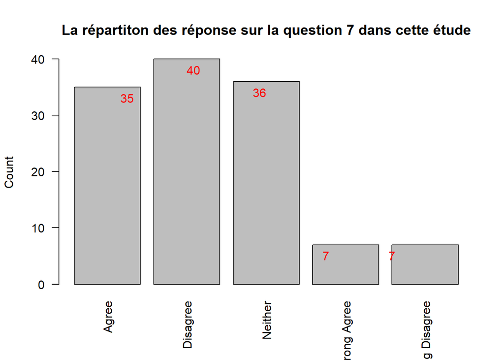

```r
Cat_plot(data$X7,"La répartiton des réponse sur la question 7 dans cette étude")
```

## La variable question 8 :

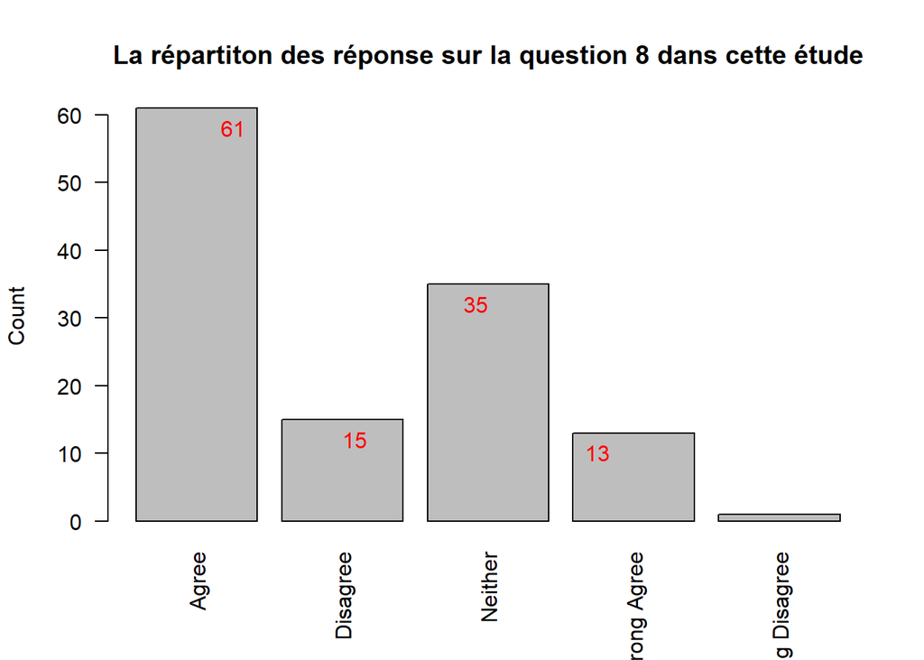

```r
Cat_plot(data$X8,"La répartiton des réponse sur la question 8 dans cette étude")
```

## La variable question 9 :

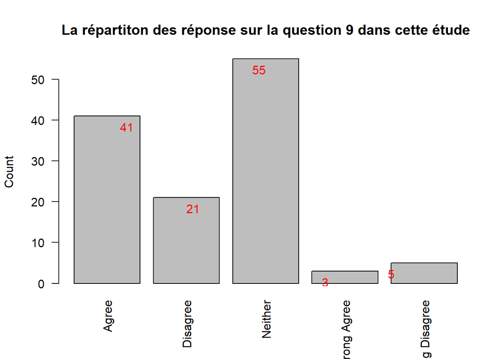

```r
Cat_plot(data$X9,"La répartiton des réponse sur la question 9 dans cette étude")
```

## La variable question 10 :

Au total, 57 élèves ont déclaré être fortement d’accord ou d’accord avec l’énoncé selon lequel ils planifient leurs activités. 34 élèves n’ont répondu ni l’un ni l’autre.

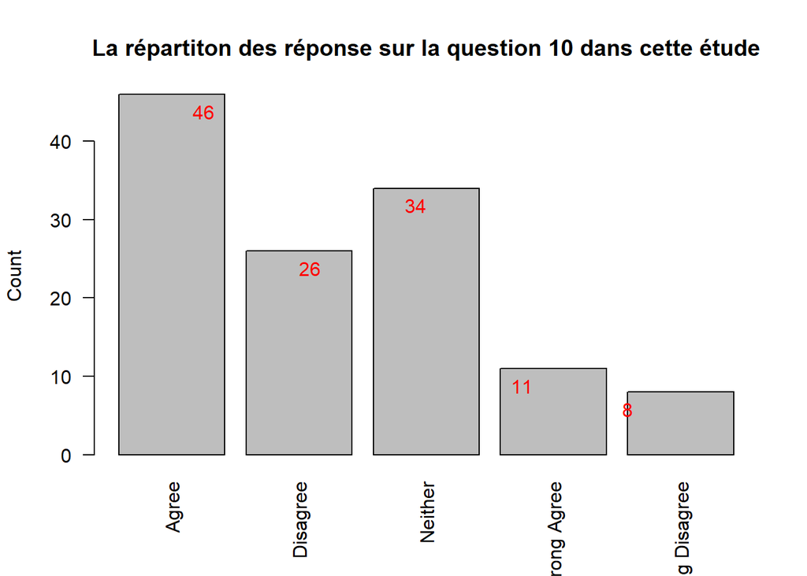

```r
Cat_plot(data$X10,"La répartiton des réponse sur la question 10 dans cette étude")
```

## La variable question 11 :

La plupart des étudiants (38) ont déclaré qu’ils n’étaient pas d’accord avec l’affirmation selon laquelle ils avaient laissé les choses à la dernière minute. 31 ont dit qu’ils étaient d’accord pour laisser les choses à la dernière minute.

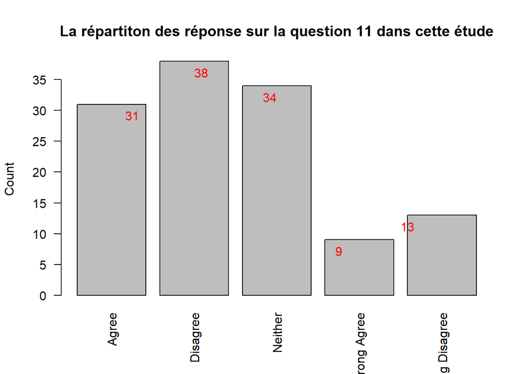

```r
Cat_plot(data$X11,"La répartiton des réponse sur la question 11 dans cette étude")
```

## La variable question 12 :

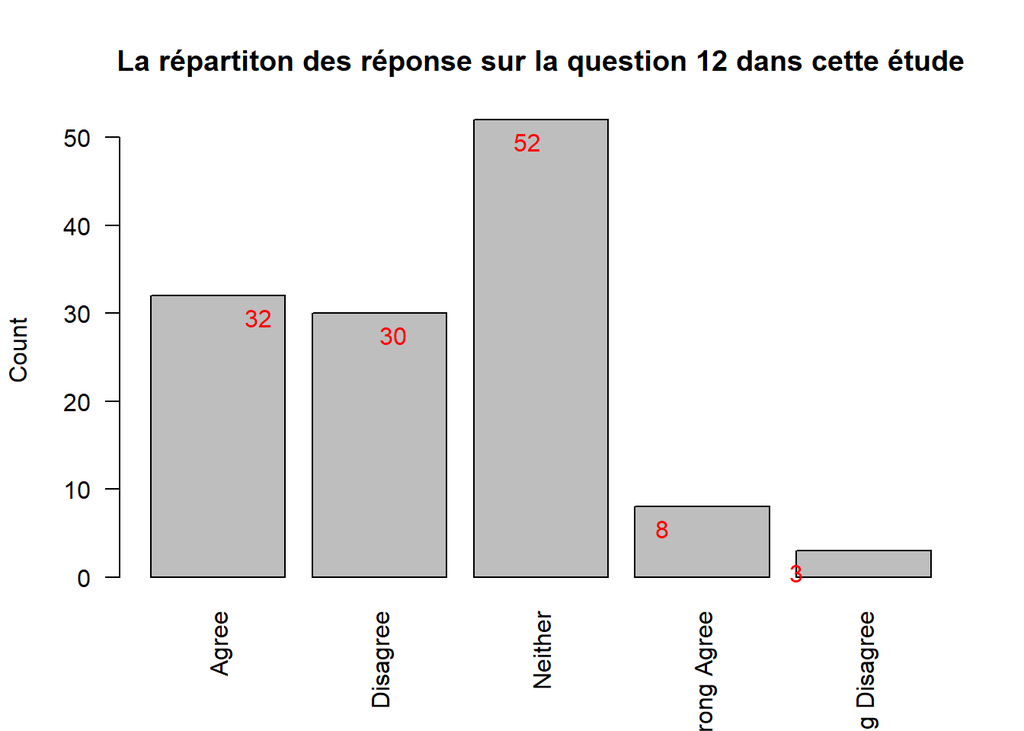

```r
Cat_plot(data$X12,"La répartiton des réponse sur la question 12 dans cette étude")
```

## La variable question 13 :

Plus d’étudiants (42 + 39 = 81) ont dit qu’ils étaient en désaccord/pas du tout d’accord que d’accord/tout à fait d’accord (13 + 5 = 18) lorsqu’il s’agissait d’abandonner les choses qu’ils avaient prévu de faire simplement parce que leur ami avait dit non.

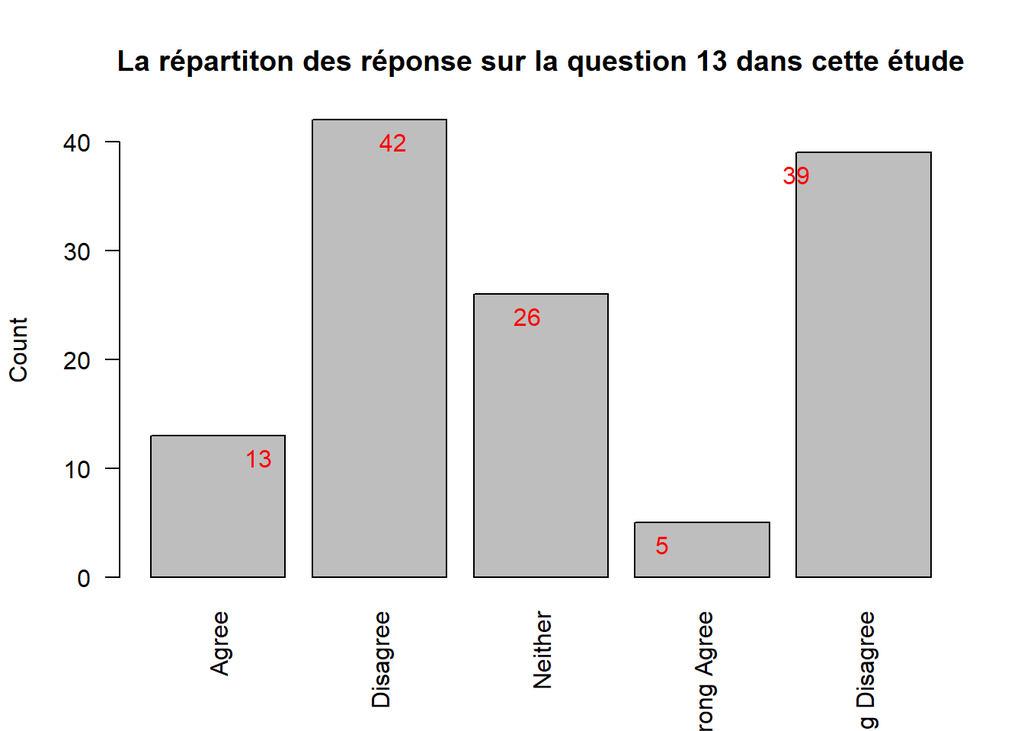

```r
Cat_plot(data$X13,"La répartiton des réponse sur la question 13 dans cette étude")
```

## La variable question 14 :

47 étudiants étaient d’accord/tout à fait d’accord qu’ils avaient fait assez de leur temps, et c’était la majorité des étudiants interrogés. 41 étudiants ont fait le chemin inverse avec leurs réponses et 37 n’ont dit ni l’un ni l’autre.

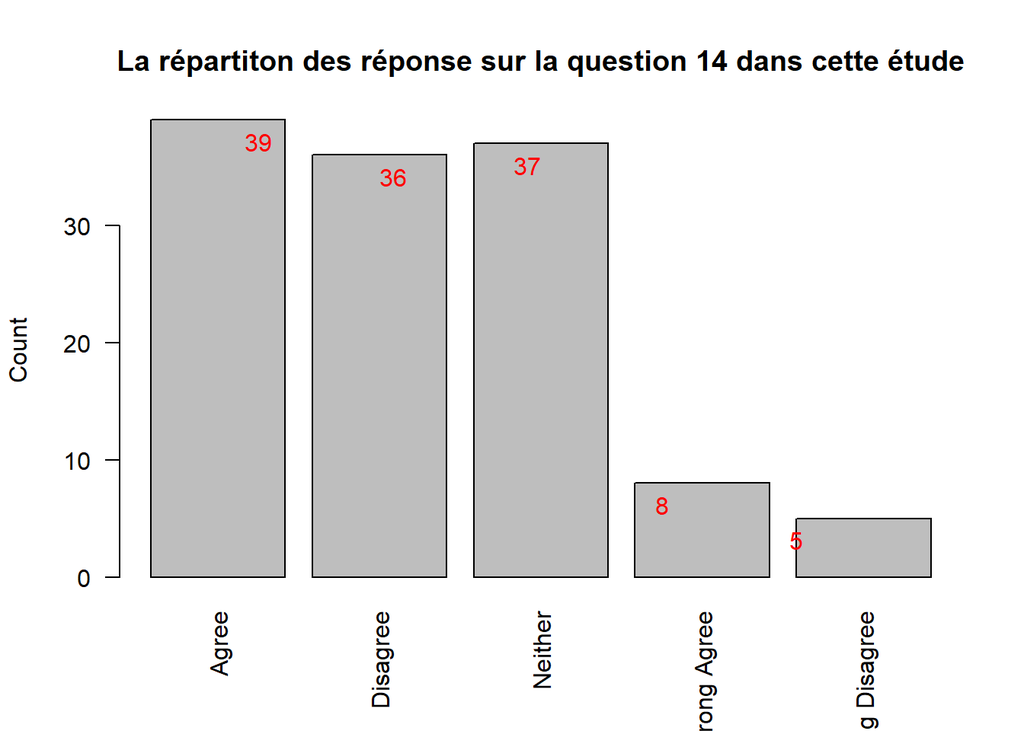

```r
Cat_plot(data$X14,"La répartiton des réponse sur la question 14 dans cette étude")
```

## La variable question 15 :

La réponse la plus élevée à la question si les étudiants s’ennuient facilement avec leurs activités quotidiennes d’aujourd’hui était la réponse Neither avec 39 étudiants et est suivie par ceux qui étaient d’accord (36) qu’ils s’ennuient facilement avec leurs activités quotidiennes.

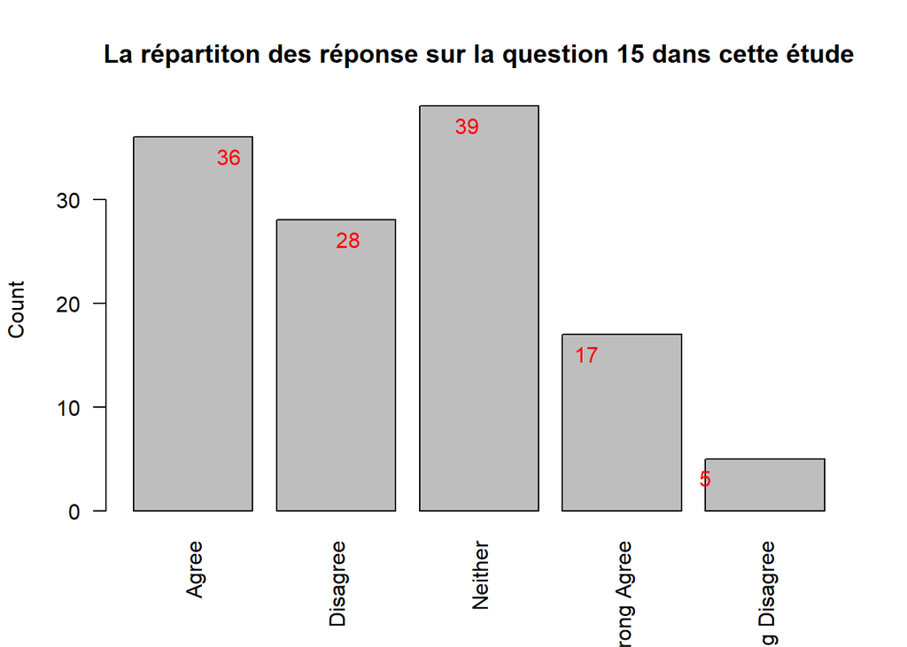

```r
Cat_plot(data$X15,"La répartiton des réponse sur la question 15 dans cette étude")
```

## La variable question 16 :

47 étudiants ont déclaré que leurs intérêts/activités importants dans leur vie avaient tendance à changer fréquemment. Cette réponse comptait le plus grand nombre d’étudiants et était suivie par ceux qui n’étaient pas d’accord (31).

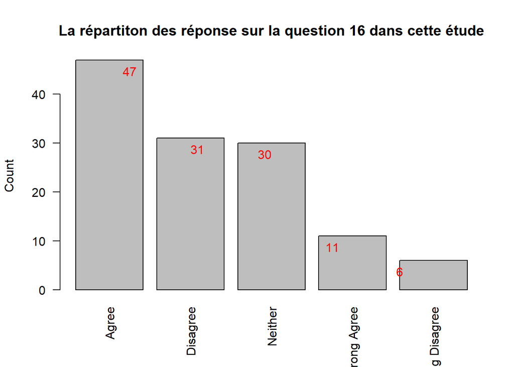

```r
Cat_plot(data$X16,"La répartiton des réponse sur la question 16 dans cette étude")
```

## La variable question 17 :

Plus d’élèves étaient d’accord (45) que pas d’accord (29) avec l’énoncé selon lequel ils savent combien de temps ils consacrent aux devoirs qu’ils font.

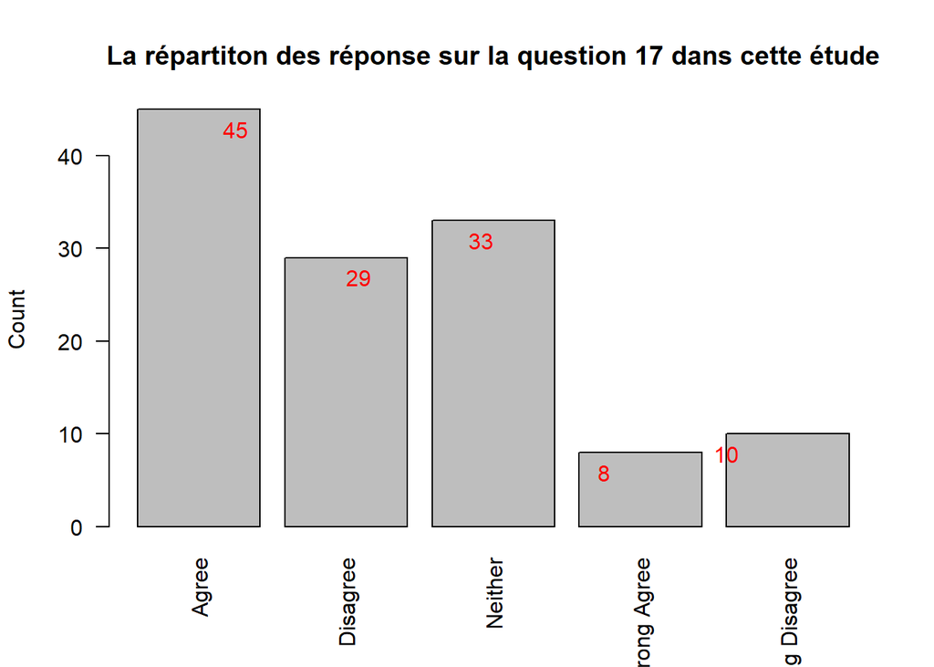

```r
Cat_plot(data$X17,"La répartiton des réponse sur la question 17 dans cette étude")
```

# Préparation à l’AFCm

Pour faire l’AFCM ou l’AFC il faut charger le package FactoMineR :

```r
library(FactoMineR)
library(factoextra)
```

On a remarqué que la variable nationality possède un nombre de modalité important par rapport aux autres variables, donc on va l’éliminer, Aussi quelques variables ont le meme nom des modalités donc nous allons les renommer . Et pour pouvoir transformer notre dataset à un tableau disjonctif complet, il faut d’abord transformer les colonnes au type factor :

```r
data$Nationality <- NULL

data$English <- paste("English",data$English,sep ="_")
data$Academic <- paste("Academic",data$Academic,sep ="_")
data$X6 <- paste("X6",data$X6,sep = "_")
data$X7 <- paste("X7",data$X7,sep ="_")
data$X8 <- paste("X8",data$X8,sep ="_")
data$X9 <- paste("X9",data$X9,sep ="_")
data$X10 <- paste("X10",data$X10,sep ="_")
data$X11 <- paste("X11",data$X11,sep ="_")
data$X12 <- paste("X12",data$X12,sep ="_")
data$X13 <- paste("X13",data$X13,sep ="_")
data$X14 <- paste("X14",data$X14,sep ="_")
data$X15 <- paste("X15",data$X15,sep ="_")
data$X16 <- paste("X16",data$X16,sep ="_")
data$X17 <- paste("X17",data$X17,sep ="_")

J <- 0

for(i in 1: ncol(data)){
  data[,i] <- as.factor(data[,i])
  J <- J + length(levels(data[,i]))
}

print(c("Nombre total de modaliés : " ,J))
```

```
## [1] "Nombre total de modaliés : " "94"
```

```r
tdc <- tab.disjonctif(data)
df <- as.data.frame(tdc)
```

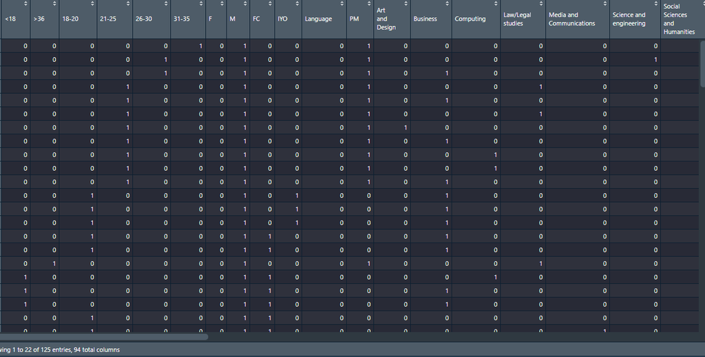

tableau disjonctif complet

```r
n <- nrow(df)

i <- 1

while( i <= ncol(df) ){

  ns <- sum(df[,i])


  if( ns < 5  ){
    df[,i] <- NULL
    i <- 1
  }

  i <- i + 1
}

print(ncol(df))
```

```
## [1] 83
```

# AFCM sur le questionnaire :

```r
acm <- CA(df,graph = F)
```

## valeurs propres :

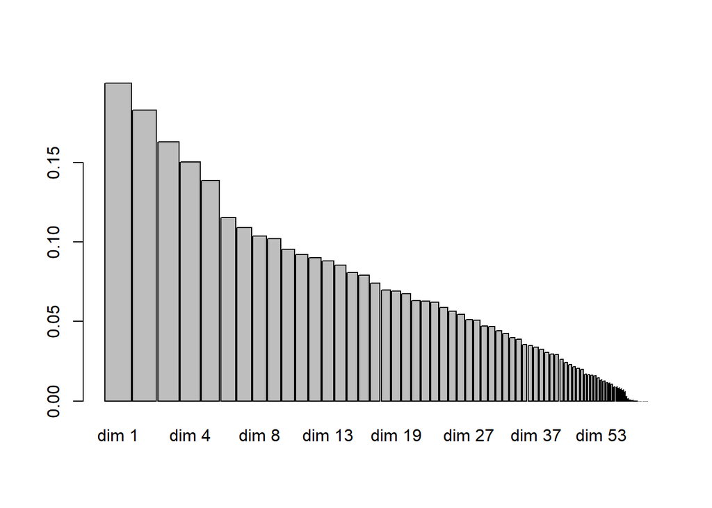

```r
barplot(acm$eig[,1],acm$eig[,2])
```

On remarque que pour avoir un pourcentage d’interie d’au moins 80% il faut prendre les 31 premiers axes factoriels :

```r
acm$eig[,3]
```

```
##      dim 1      dim 2      dim 3      dim 4      dim 5      dim 6      dim 7
##   5.829481  11.165566  15.917393  20.304632  24.347954  27.713406  30.893056
##      dim 8      dim 9     dim 10     dim 11     dim 12     dim 13     dim 14
##  33.919162  36.899582  39.679400  42.365337  44.994096  47.559384  50.045942
##     dim 15     dim 16     dim 17     dim 18     dim 19     dim 20     dim 21
##  52.396586  54.702764  56.861417  58.892092  60.906383  62.871171  64.707398
##     dim 22     dim 23     dim 24     dim 25     dim 26     dim 27     dim 28
##  66.539137  68.353759  70.066838  71.708648  73.300710  74.795141  76.273933
##     dim 29     dim 30     dim 31     dim 32     dim 33     dim 34     dim 35
##  77.649512  79.009750  80.300424  81.541513  82.697804  83.827639  84.863634
##     dim 36     dim 37     dim 38     dim 39     dim 40     dim 41     dim 42
##  85.881294  86.867772  87.811578  88.698195  89.561735  90.413777  91.172662
##     dim 43     dim 44     dim 45     dim 46     dim 47     dim 48     dim 49
##  91.874625  92.543737  93.173313  93.773420  94.353767  94.846563  95.333173
##     dim 50     dim 51     dim 52     dim 53     dim 54     dim 55     dim 56
##  95.805537  96.267783  96.688434  97.073552  97.434829  97.768433  98.098014
##     dim 57     dim 58     dim 59     dim 60     dim 61     dim 62     dim 63
##  98.409787  98.672418  98.928277  99.165197  99.387126  99.588315  99.758696
##     dim 64     dim 65     dim 66     dim 67     dim 68     dim 69     dim 70
##  99.845942  99.891737  99.920066  99.942847  99.962533  99.975339  99.985640
##     dim 71     dim 72     dim 73     dim 74     dim 75     dim 76     dim 77
##  99.992352  99.997061 100.000000 100.000000 100.000000 100.000000 100.000000
##     dim 78     dim 79     dim 80     dim 81     dim 82
## 100.000000 100.000000 100.000000 100.000000 100.000000
```

## le biplot individus-variables :

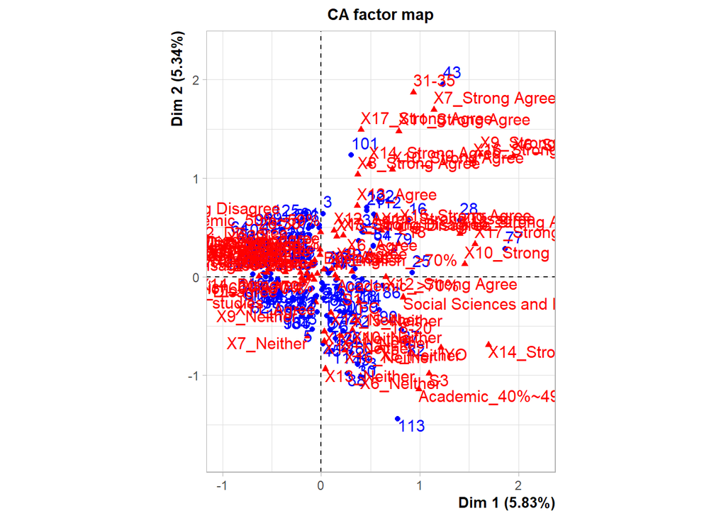

```r
plot.CA(acm)
```

## Etude du tableau des contributions:

Une variable contribue bien à la construction du premier axe si sa contribution absolue est supérieue à son poids :

```r
contribCol <- as.data.frame(acm$col$contrib)
coordCol <- as.data.frame(acm$col$coord)

contribRow <- as.data.frame(acm$row$contrib)
coordRow <- as.data.frame(acm$row$coord)

print("######### Les variables qui contribuent le plus à la construction du premier axe ######### ")
```

```
## [1] "######### Les variables qui contribuent le plus à la construction du premier axe ######### "
```

```r
for(i in 1:ncol(df)){

      ns <- sum(df[,i])
      fs <- ns /n

      if(contribCol$`Dim 1`[i] >= fs*100 && coordCol$`Dim 1`[i] > 0){
        print(c(colnames(df)[i],"+"))
      }
      if(contribCol$`Dim 1`[i] >= fs*100 && coordCol$`Dim 1`[i] < 0){
        print(c(colnames(df)[i],"-"))
      }
}
```

```
## [1] "X6_Strong Agree" "+"
```

```r
print("######### Les individus qui contribuent le plus à la construction du premier axe ######### ")
```

```
## [1] "######### Les individus qui contribuent le plus à la construction du premier axe ######### "
```

```r
for(i in 1:nrow(df)){


      if(contribRow$`Dim 1`[i] > 100/n && coordRow$`Dim 1`[i] > 0){
        print(c(i,"+"))
      }
      if(contribRow$`Dim 1`[i] > 100/n && coordRow$`Dim 1`[i] < 0){
        print(c(i,"-"))
      }
}
```

```
## [1] "4" "-"
## [1] "7" "-"
## [1] "16" "+"
## [1] "20" "+"
## [1] "25" "+"
## [1] "27" "+"
## [1] "28" "+"
## [1] "38" "-"
## [1] "43" "+"
## [1] "46" "-"
## [1] "54" "+"
## [1] "58" "-"
## [1] "61" "-"
## [1] "62" "-"
## [1] "64" "-"
```

[output cut: 21 more lines]

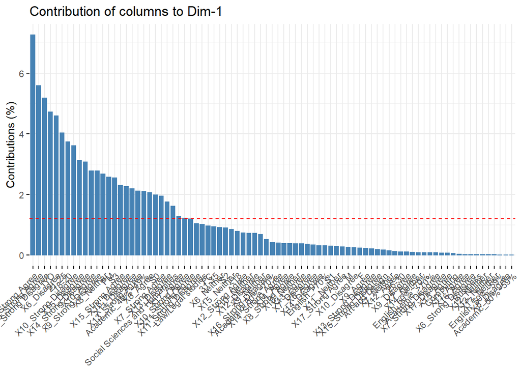

```r
fviz_contrib(acm, choice ="col", axes = 1)
```

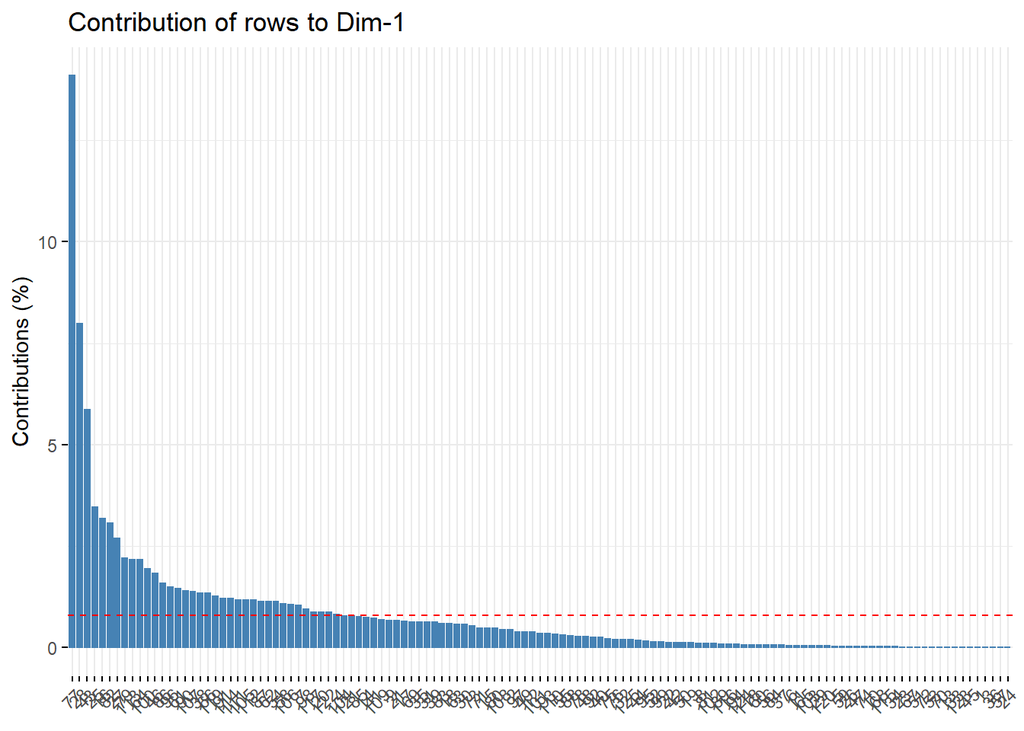

```r
fviz_contrib(acm, choice ="row", axes = 1)
```

On déduit que le premier axe est à effet taille, il caractèrise les individus qui ont répondu à la question 6 avec ” tout à fait d’accord “, représenté par les individus 16,20,25,27,28,43,54,77,79,82,86,87,90,112,113,122 contrairement aux individus 4,7,38,46,58,61,62,64,66,91,96,98,100,105,106,107,111,114,117,119 qui ont été en désaccord avec la question 6

```r
print("######### Les variables qui contribuent le plus à la construction du 2ème axe ######### ")
```

```
## [1] "######### Les variables qui contribuent le plus à la construction du 2ème axe ######### "
```

```r
for(i in 1:ncol(df)){

      ns <- sum(df[,i])
      fs <- ns /n

      if(contribCol$`Dim 2`[i] > fs*100 && coordCol$`Dim 2`[i] > 0){
        print(c(colnames(df)[i],"+"))
      }
      if(contribCol$`Dim 2`[i] > fs*100 && coordCol$`Dim 2`[i] < 0){
        print(c(colnames(df)[i],"-"))
      }

}
```

```
## [1] "31-35" "+"
```

```r
print("######### Les individus qui contribuent le plus à la construction du 2ème axe ######### ")
```

```
## [1] "######### Les individus qui contribuent le plus à la construction du 2ème axe ######### "
```

```r
for(i in 1:nrow(df)){


      if(contribRow$`Dim 2`[i] > 100/n && coordRow$`Dim 2`[i] > 0){
        print(c(i,"+"))
      }
      if(contribRow$`Dim 2`[i] > 100/n && coordRow$`Dim 2`[i] < 0){
        print(c(i,"-"))
      }
}
```

```
## [1] "1" "+"
## [1] "3" "+"
## [1] "5" "-"
## [1] "6" "+"
## [1] "11" "-"
## [1] "16" "+"
## [1] "20" "+"
## [1] "26" "-"
## [1] "27" "-"
## [1] "28" "+"
## [1] "30" "-"
## [1] "31" "+"
## [1] "36" "+"
## [1] "43" "+"
## [1] "45" "-"
```

[output cut: 17 more lines]

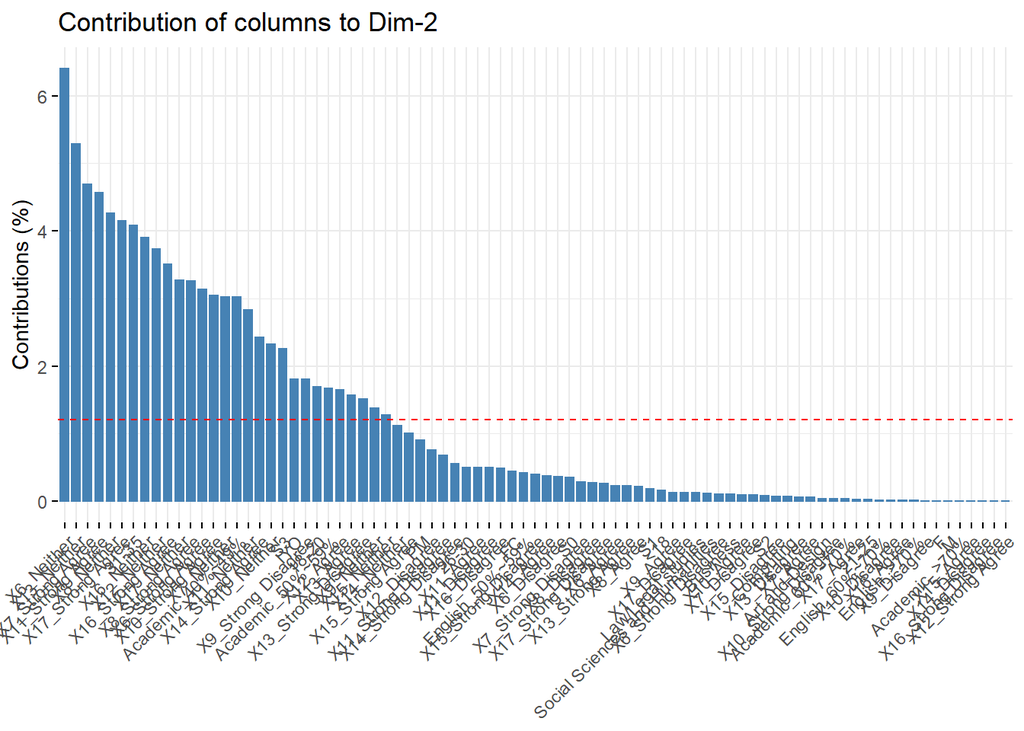

```r
fviz_contrib(acm, choice ="col", axes = 2)
```

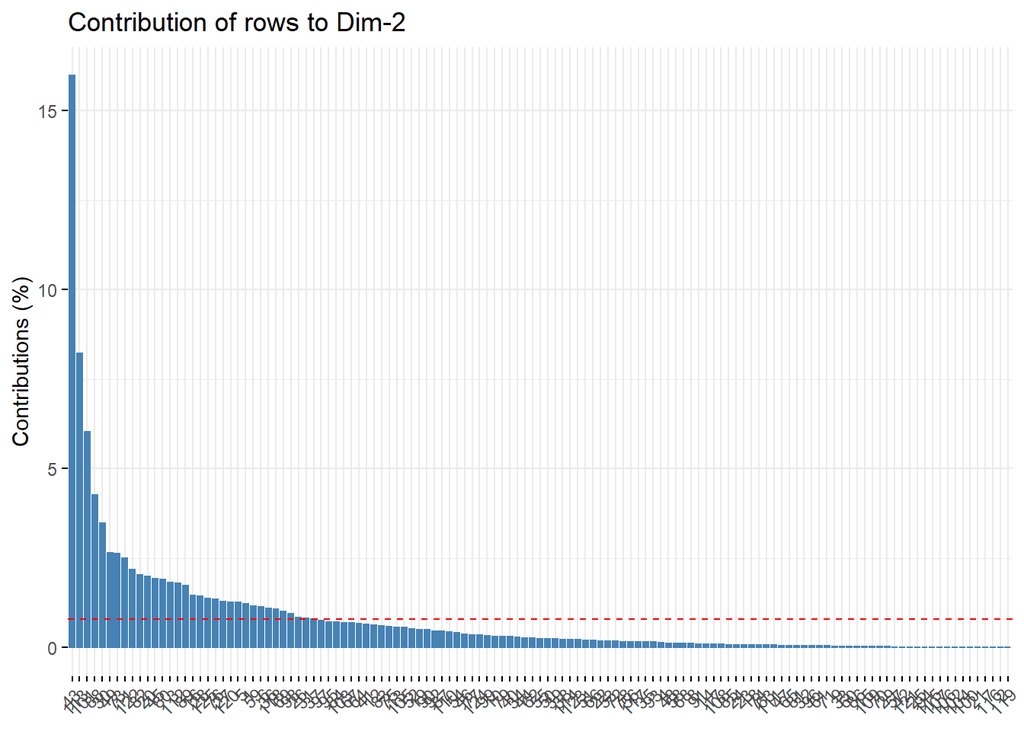

```r
fviz_contrib(acm, choice ="row", axes = 2)
```

On remarque que certaines individus n’ont pas un age entre 31 et 35 mais ils representent cet axe, on conclut donc que ces individus sont mal représentés. Or on remarque aussi que ce premier plan factoriel ne représente que 11.16% de l’information contenue dans notre jeu de données.

## Les fortes association qu’on peut ressortir de l’AFCM :

Ceux qui ont un age compris entre 31 et 35 ont tendance à étre tout à fait d’accord avec la question 7

```r
# for (i in 1:ncol(df)){
#   for(j in 1:ncol(df)){
#
#
#     if( sqrt( ( coordCol$`Dim 1`[i] - coordCol$`Dim 1`[j] )**2 + ( coordCol$`Dim 2`[i] - coordCol$`Dim 2`[j] )**2 )  < 1 && i != j){
#       print(c(colnames(df)[i],colnames(df)[j]))
#     }
#   }
# }
```

## Les questions les mieux représentées par l’AFCM :

```r
cosCol <- as.data.frame(acm$col$cos2)

print("######### Les variables les mieux représentées par le  premier axe ######### ")
```

```
## [1] "######### Les variables les mieux représentées par le  premier axe ######### "
```

```r
for(i in 1:ncol(df)){


      if(cosCol$`Dim 1`[i] >= 0.2 ){
        print(colnames(df)[i])
      }
}
```

```
## [1] "21-25"
## [1] "IYO"
## [1] "PM"
## [1] "X6_Disagree"
## [1] "X6_Strong Agree"
## [1] "X16_Strong Agree"
## [1] "X17_Strong Disagree"
```

```r
print("######### Les variables les mieux représentées par le 2ème axe ######### ")
```

```
## [1] "######### Les variables les mieux représentées par le 2ème axe ######### "
```

```r
for(i in 1:ncol(df)){


      if(cosCol$`Dim 2`[i] >= 0.2 ){
        print(colnames(df)[i])
      }
}
```

```
## [1] "X6_Neither"
## [1] "X8_Neither"
## [1] "X12_Neither"
## [1] "X13_Neither"
```

# AFC sur deux questions :

## Croiser 2 questions :

on croise la variable académique [ les notes obtenues dans le cours acadèmique] à la variable attendance [ nombre d’absence : s0 = faible, s4 elevé]

```r
tc <- table(data$Academic,data$Attendance)
tc
```

```
##
##                    S0 S1 S2 S3 S4
##   Academic_<40%     0  0  0  1  1
##   Academic_>70%     7  4  1  0  1
##   Academic_40%~49%  2  3  0  5  0
##   Academic_50%~59% 13 13  6  3  0
##   Academic_60%~70% 47 10  6  1  1
```

```r
afc <- CA(tc)
```

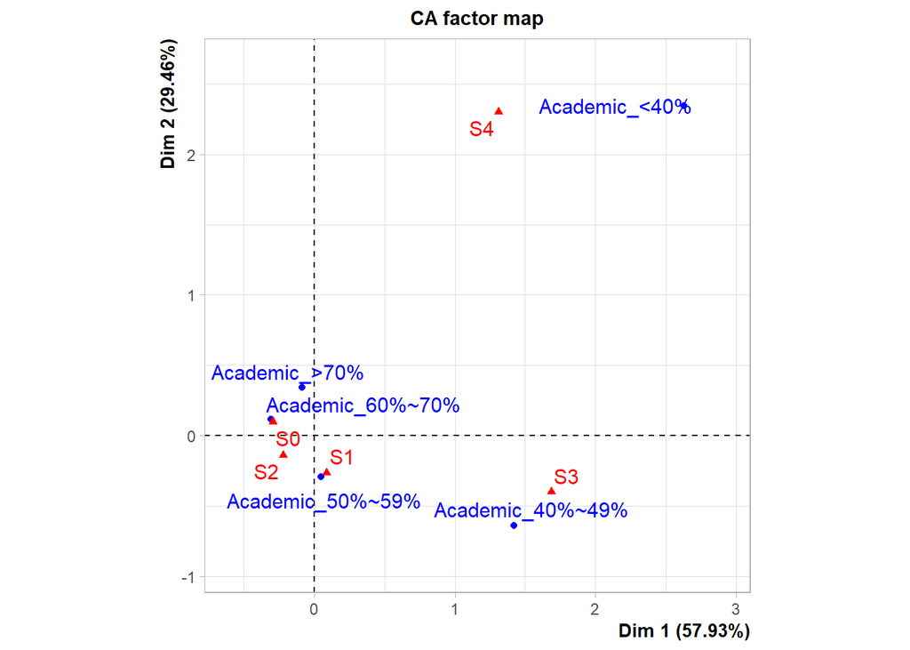

## valeurs propres :

On remarque qu’avec seulement les 2 premiers axe on a une tres bonne représentation

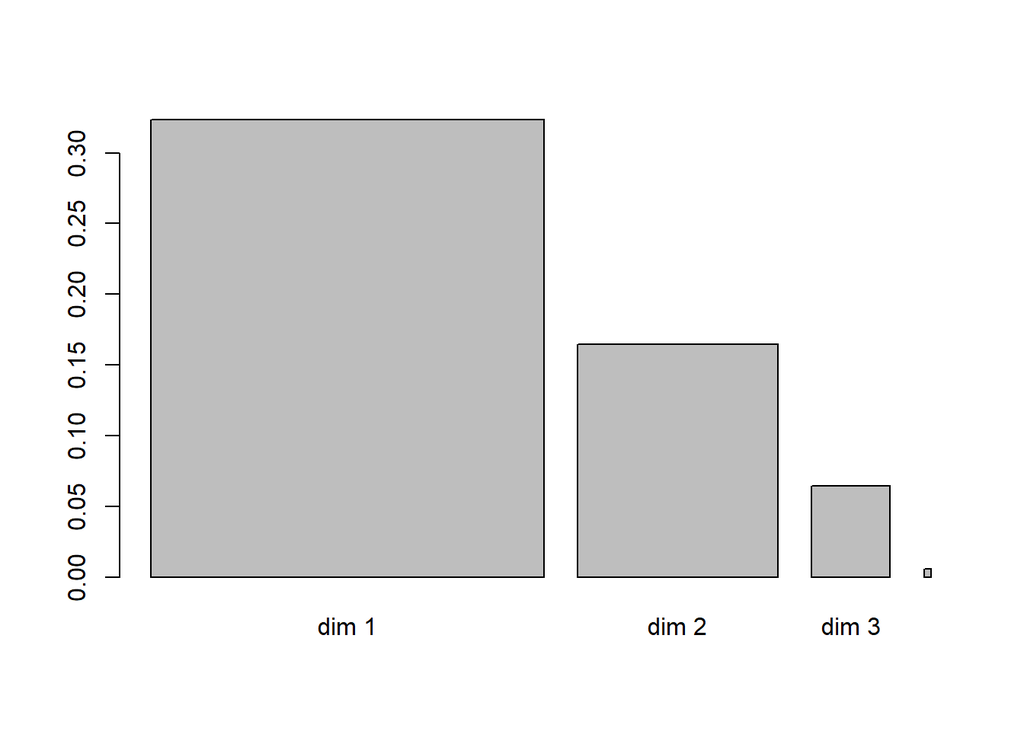

```r
barplot(afc$eig[,1],afc$eig[,2])
```

## Etude du tableau des contributions:

```r
contribCol <- as.data.frame(afc$col$contrib)
coordCol <- as.data.frame(afc$col$coord)

contribRow <- as.data.frame(afc$row$contrib)
coordRow <- as.data.frame(afc$row$coord)

print("######### Les profile colonnes qui contribuent le plus à la construction du premier axe ######### ")
```

```
## [1] "######### Les profile colonnes qui contribuent le plus à la construction du premier axe ######### "
```

```r
for(i in 1:ncol(tc)){

      ns <- sum(tc[,i])
      fs <- ns /n

      if(contribCol$`Dim 1`[i] >= fs*100 && coordCol$`Dim 1`[i] > 0){
        print(c(colnames(tc)[i],"+"))
      }
      if(contribCol$`Dim 1`[i] >= fs*100 && coordCol$`Dim 1`[i] < 0){
        print(c(colnames(tc)[i],"-"))
      }
}
```

```
## [1] "S3" "+"
## [1] "S4" "+"
```

```r
print("######### Les profiles lignes qui contribuent le plus à la construction du premier axe ######### ")
```

```
## [1] "######### Les profiles lignes qui contribuent le plus à la construction du premier axe ######### "
```

```r
for(i in 1:nrow(tc)){

      ns <- sum(tc[i,])
      fs <- ns /n

      if(contribRow$`Dim 1`[i] > fs*100 && coordRow$`Dim 1`[i] > 0){
        print(c(rownames(tc)[i],"+"))
      }
      if(contribRow$`Dim 1`[i] > fs*100 && coordRow$`Dim 1`[i] < 0){
        print(c(rownames(tc)[i],"-"))
      }
}
```

```
## [1] "Academic_<40%" "+"
## [1] "Academic_40%~49%" "+"
```

On déduit que le premier axe est à effet taille, il quantifie les classes qui ont beaucoup d’absences [s3] représenté par les individus qui ont des moyennes comprises entre 49% et 40% dans les cours académique et aussi les classes qui ont énormément d’absences [s4] représenté par les individus qui ont des moyennes inférieure à 40%.

```r
print("######### Les profile colonnes qui contribuent le plus à la construction du 2ème axe ######### ")
```

```
## [1] "######### Les profile colonnes qui contribuent le plus à la construction du 2ème axe ######### "
```

```r
for(i in 1:ncol(tc)){

      ns <- sum(tc[,i])
      fs <- ns /n

      if(contribCol$`Dim 2`[i] >= fs*100 && coordCol$`Dim 2`[i] > 0){
        print(c(colnames(tc)[i],"+"))
      }
      if(contribCol$`Dim 2`[i] >= fs*100 && coordCol$`Dim 2`[i] < 0){
        print(c(colnames(tc)[i],"-"))
      }
}
```

```
## [1] "S4" "+"
```

```r
print("######### Les profiles lignes qui contribuent le plus à la construction du 2ème axe ######### ")
```

```
## [1] "######### Les profiles lignes qui contribuent le plus à la construction du 2ème axe ######### "
```

```r
for(i in 1:nrow(tc)){

      ns <- sum(tc[i,])
      fs <- ns /n

      if(contribRow$`Dim 2`[i] > fs*100 && coordRow$`Dim 2`[i] > 0){
        print(c(rownames(tc)[i],"+"))
      }
      if(contribRow$`Dim 2`[i] > fs*100 && coordRow$`Dim 2`[i] < 0){
        print(c(rownames(tc)[i],"-"))
      }
}
```

```
## [1] "Academic_<40%" "+"
## [1] "Academic_40%~49%" "-"
```

Aussi le 2ème axe est à effet taille, il quantifie les classes qui ont beaucoup beacoup d’absences [s4] représenté par les individus qui ont des moyenne inferieure à 40% dans les cours académique.

# Conclusion :

D’aprés les résultats obtenus on conclut que :

- Les étudiant qui s’absentent beaucoup ont tendance à avoir des moyennes faibles inférieure à 40%